# InVivoStat Single Measure Parametric Analysis

## Response

The Resp 1 response is currently being analysed by the Single Measures Parametric Analysis module.The response has been square root transformed prior to analysis.

## Scatterplot of the observed data (on the square root scale)

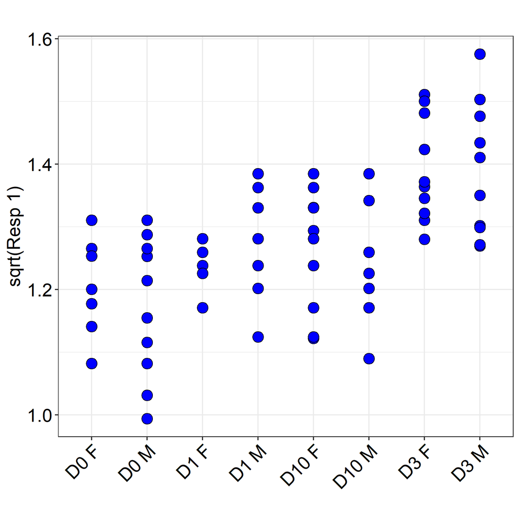

Tip: Use this plot to identify possible outliers.

## Analysis of variance (ANOVA) table

| Effect | Sums of squares | Degrees of freedom | Mean square | F-value | p-value |
| --- | --- | --- | --- | --- | --- |
| Blo ck1 | 0.001 | 1 | 0.001 | 0.08 | 0.7811 |
| Blo ck2 | 0.016 | 2 | 0.008 | 0.91 | 0.4066 |
| Treat1 | 0.452 | 3 | 0.151 | 17.05 | < 0.0001 |
| Treat2 | 0.000 | 1 | 0.000 | 0.00 | 0.9829 |
| Treat1 * Treat2 | 0.019 | 3 | 0.006 | 0.73 | 0.5354 |
| Residual | 0.592 | 67 | 0.009 |  |  |

Comment: ANOVA table calculated using a Type III model fit, see Armitage et al. (2001).

Conclusion: At the 5% level, there is a statistically significant overall difference between the levels of Treat1.

Tip: While it is a good idea to consider the overall tests in the ANOVA table, we should not rely on them when deciding whether or not to make pairwise comparisons.

## Model coefficients

|  | Estimate | Std. Error | t-value | p-value |
| --- | --- | --- | --- | --- |
| (Intercept) | 1.2659 | 0.0107 | 118.56 | < 0.0001 |
| Blo ck11 | -0.0030 | 0.0106 | -0.28 | 0.7811 |
| Blo ck21 | 0.0196 | 0.0151 | 1.29 | 0.2000 |
| Blo ck22 | -0.0048 | 0.0152 | -0.31 | 0.7539 |
| Treat11 | -0.0862 | 0.0190 | -4.53 | < 0.0001 |
| Treat12 | -0.0184 | 0.0183 | -1.00 | 0.3200 |
| Treat13 | -0.0193 | 0.0183 | -1.05 | 0.2964 |
| Treat21 | 0.0002 | 0.0107 | 0.02 | 0.9829 |
| Treat11:Treat21 | 0.0083 | 0.0191 | 0.44 | 0.6643 |
| Treat12:Treat21 | -0.0247 | 0.0184 | -1.35 | 0.1829 |
| Treat13:Treat21 | 0.0174 | 0.0183 | 0.95 | 0.3459 |

## Diagnostic plots

### Residuals vs. predicted plot

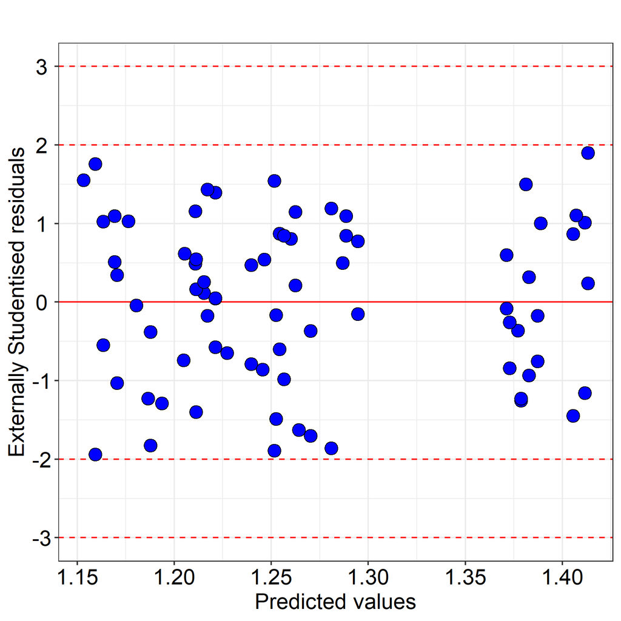

Tip: On this plot look to see if the spread of the points increases as the predicted values increase. If so the response may need transforming.

Tip: Any observation with a residual less than -3 or greater than 3 (SD) should be investigated as a possible outlier.

### Normal probability plot

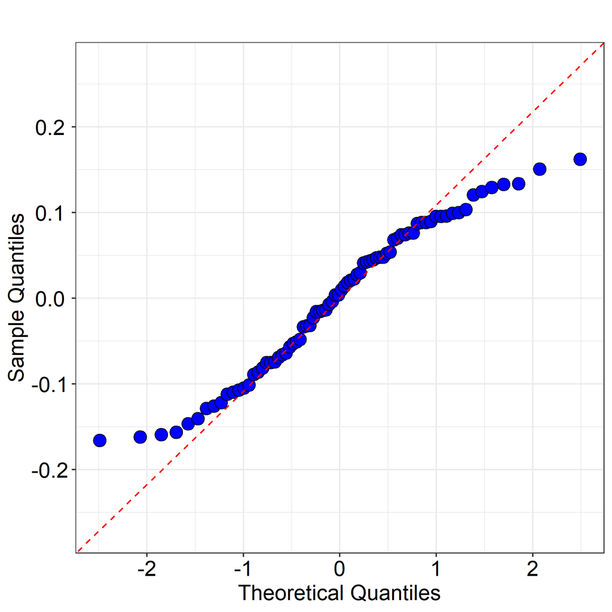

Tip: Check that the points lie along the dotted line. If not then the data may be non-normally distributed.

## Table of the least square (predicted) means with 95% confidence intervals

| Mean ID | Treat2 | Mean | Lower 95% CI | Upper 95% CI |
| --- | --- | --- | --- | --- |
| 1 | F | 1.266 | 1.236 | 1.297 |
| 2 | M | 1.266 | 1.236 | 1.295 |

## Plot of the least square (predicted) means with 95% confidence intervals

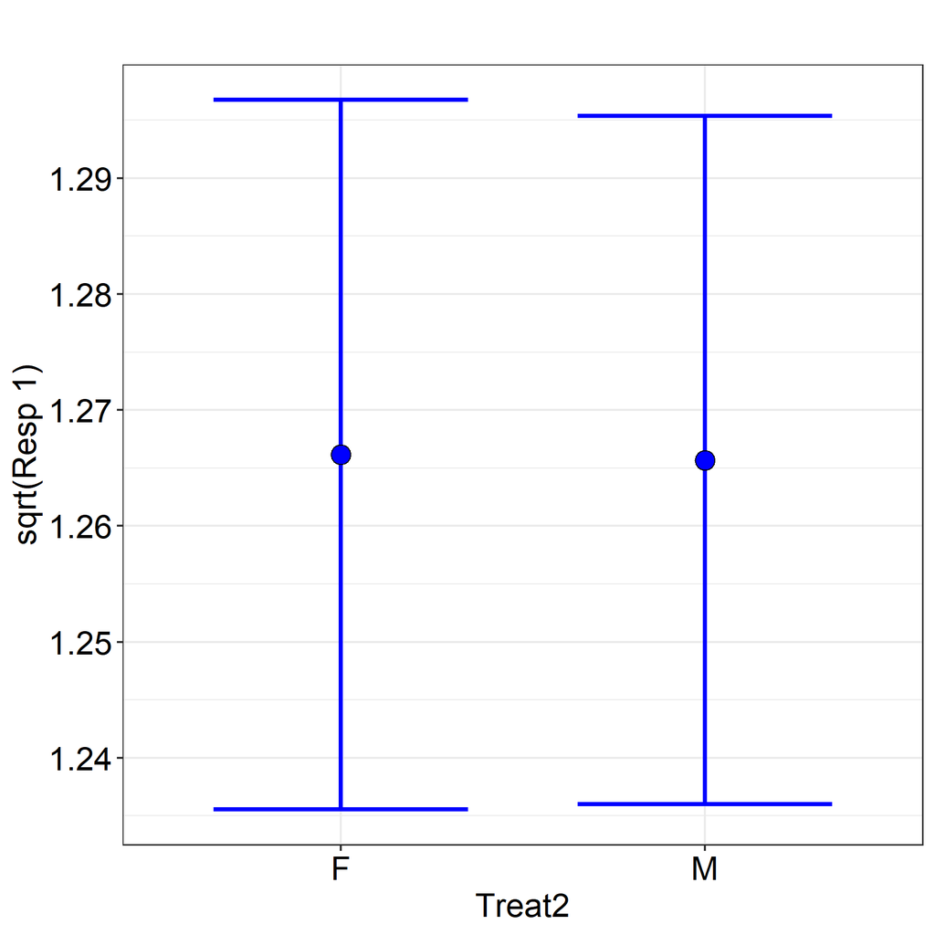

## All pairwise comparisons without adjustment for multiplicity (LSD test)

| Comparison | Difference | Lower 95% CI | Upper 95% CI | Std error | p-value |
| --- | --- | --- | --- | --- | --- |
| F - M | 0.000 | -0.042 | 0.043 | 0.021 | 0.9829 |

Conclusion: At the 5% level, the pairwise comparison is not statistically significant.

Warning: It is not advisable to draw statistical inferences about a factor/interaction in the presence of a significant higher-order interaction involving that factor/interaction.

## All to one comparisons without adjustment for multiplicity (LSD test)

| Comparison | Difference | Lower 95% CI | Upper 95% CI | Std error | p-value |
| --- | --- | --- | --- | --- | --- |
| M - F | 0.000 | -0.043 | 0.042 | 0.021 | 0.9829 |

## Plot of the comparisons between the predicted means with 95% confidence intervals

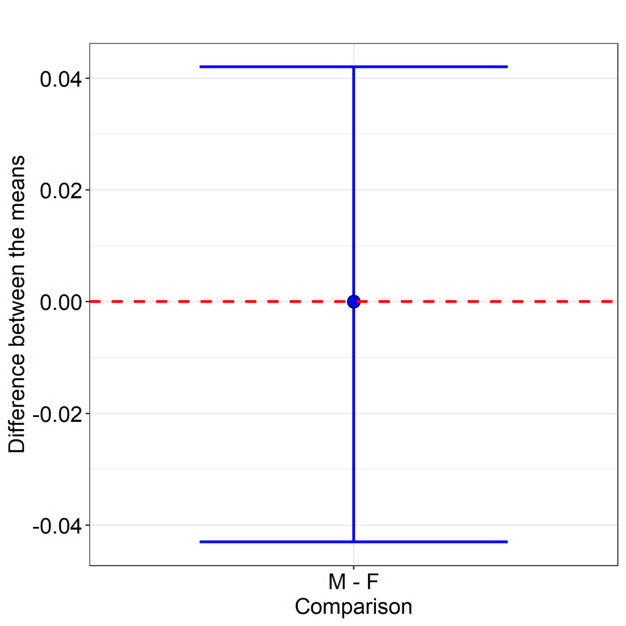

Conclusion: At the 5% level, the pairwise comparison is not statistically significant.

Warning: It is not advisable to draw statistical inferences about a factor/interaction in the presence of a significant higher-order interaction involving that factor/interaction. In the above table certain higher order interactions are assumed to be not significant, see log for more details.

## Analysis description

The data were analysed using a 2-way ANOVA approach, with Treat1 and Treat2 as the treatment factors and Blo ck1 and Blo ck2 as the blocking factors. This was followed by Planned Comparisons of the predicted means to compare the levels of the Treat2 factor, Snedecor and Cochran (1989). The response was square root transformed prior to analysis to stabilise the variance.

For more information on the theoretical approaches that are implemented within this module, see Bate and Clark (2014).

## References

When referring to InVivoStat, please cite 'InVivoStat, version 5.2.0'.

Bate, S.T. and Clark, R.A. (2014). The Design and Statistical Analysis of Animal Experiments. Cambridge University Press.

Armitage, P., Matthews, J.N.S. and Berry, G. (2001). Statistical Methods in Medical Research. 4th edition; John Wiley & Sons. New York.